# Question

A taxi service charges a fixed base cost of $4.70 and then a mileage cost of $2.37 per mile. The following people wonder whether they can travel a specified distance with the amount of cash they are carrying.

- Can Arnold go 3.1 miles with $15.42?
  - ##ANSWER1##
- Can Betty go 18.1 miles with $36.50?
  - ##ANSWER2##
- Can Chester go 26.8 miles with $54.98?
  - ##ANSWER3##
- Can Denali go 24 miles with $80.43?
  - ##ANSWER4##
- Can Edward go 14.2 miles with $47.95?
  - ##ANSWER5##

## Answerlist

- yes
- no
- yes
- no
- yes
- no
- yes
- no
- yes
- no

# Solution

I’d recommend doing this with [Desmos](https://www.desmos.com/calculator). Start by creating the equation describing the linear equation between distance ($x$, miles) and total cost ($y$, dollars).

$$y~=~4.70+2.37x$$

A passenger needs to have **at least** the total in cash to afford the ride. If the passenger has more than enough money, they can still afford the ride. So, if we redefine $y$ to be any possible amount of pocket money, we can say $y$ must be as much **or more** than the cost of the ride.

$$y~\ge~4.70+2.37x$$

So, type that inequality into Desmos. Then type in the following points:

(3.1,15.42)

(18.1,36.5)

(26.8,54.98)

(24,80.43)

(14.2,47.95)

For each point, if it falls in the feasible region, then it is a solution to the inequality.

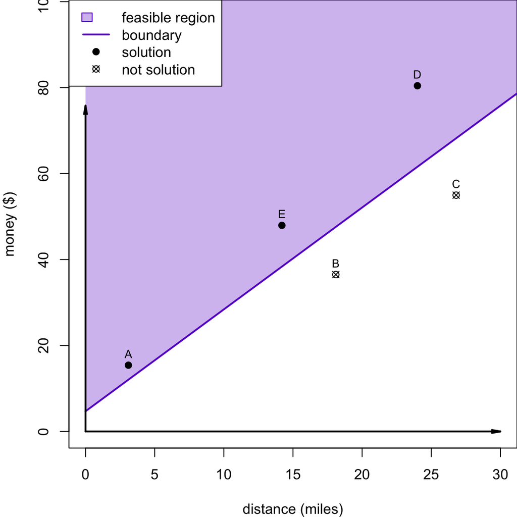

- Yes, Arnold can afford to go 3.1 miles with $15.42 in pocket.
- No, Betty can NOT afford to go 18.1 miles with $36.50 in pocket.
- No, Chester can NOT afford to go 26.8 miles with $54.98 in pocket.
- Yes, Denali can afford to go 24 miles with $80.43 in pocket.
- Yes, Edward can afford to go 14.2 miles with $47.95 in pocket.

# Meta-information

extype: cloze exclozetype: schoice|schoice|schoice|schoice|schoice exsolution: 10|01|01|10|10 exname: check_sols_ineq